# Machine Learning - Prediction Assignment

## The Goal of this project is to quantify how well people do a particular activity. In this case, we will take observations on the manner in which poeple exericse and grade them as follows: A - Exact to Specification, B - Throwing Elbows Out Front, C - Lifting Halfway, D = Lowering Halfway, E - Throwing Hips to the Front

## First, we must read in the Datafile

```r
exercise <- read.csv("pml-training.csv", header=TRUE)
```

## Next we separate the datasets using cross-validation. 75% training, 25% testing.

```r
inTrain <-createDataPartition(y=exercise$classe, p=0.75, list=FALSE)
training <- exercise[inTrain,]
testing <- exercise[-inTrain,]
dim(training)
```

```
## [1] 14718   160
```

```r
dim(testing)
```

```
## [1] 4904  160
```

```r
exercise <- subset(exercise, select=c(classe,total_accel_belt, total_accel_forearm, total_accel_arm, total_accel_dumbbell))
```

## We partitition again on new this dataset as well via cross-validation.

```r
inTrain <-createDataPartition(y=exercise$classe, p=0.75, list=FALSE)
training <- exercise[inTrain,]
testing <- exercise[-inTrain,]
```

## We have now created a new data set which we will be using going forward to build our prediciton model.We will use K Folds sampling to created 20 folds for our 20 predictions.

```r
set.seed(32323)
folds <- createFolds(y=training$classe, k=20, list=TRUE, returnTrain=TRUE)
sapply(folds,length)
```

```
## Fold01 Fold02 Fold03 Fold04 Fold05 Fold06 Fold07 Fold08 Fold09 Fold10
##  13982  13982  13982  13980  13983  13980  13983  13980  13983  13984
## Fold11 Fold12 Fold13 Fold14 Fold15 Fold16 Fold17 Fold18 Fold19 Fold20
##  13982  13981  13983  13983  13983  13981  13982  13984  13983  13981
```

## The aforementioned represent the 20 folds we have created and their length. Now we will create 20 datasets through resampling.

```r
set.seed(32323)
folds <- createResample(y=training$classe, times=20, list=TRUE)
sapply(folds, length)
```

```
## Resample01 Resample02 Resample03 Resample04 Resample05 Resample06
##      14718      14718      14718      14718      14718      14718
## Resample07 Resample08 Resample09 Resample10 Resample11 Resample12
##      14718      14718      14718      14718      14718      14718
## Resample13 Resample14 Resample15 Resample16 Resample17 Resample18
##      14718      14718      14718      14718      14718      14718
## Resample19 Resample20
##      14718      14718
```

## We have just displayed a couple of cross-validation techniques.

## Now we will displays some figures to show data relationships.

### Creating a Feature Plot

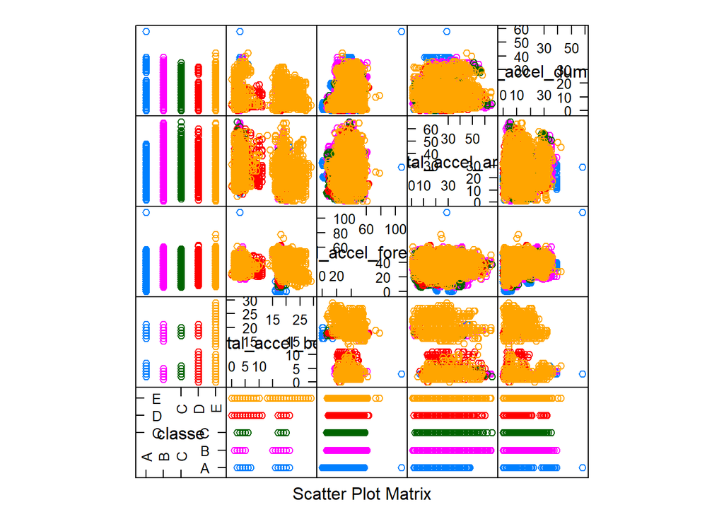

```r
featurePlot(x=training[,c("classe","total_accel_belt", "total_accel_forearm", "total_accel_arm", "total_accel_dumbbell")],
            y = training$classe, plot="pairs")
```

###Create a Qplot

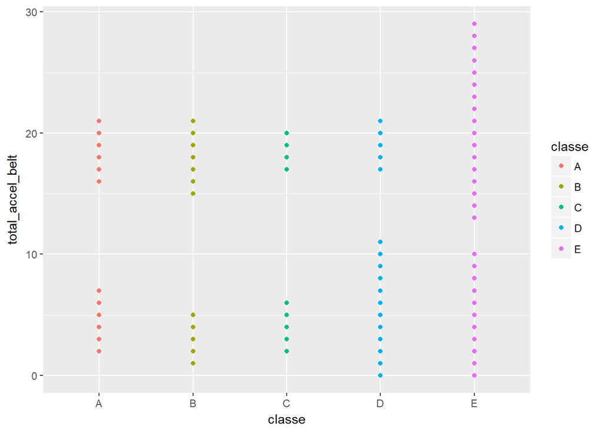

```r
qplot(classe,total_accel_belt,colour=classe, data=training)
```

```r
plot
```

```
## standardGeneric for "plot" defined from package "graphics"
##
## function (x, y, ...)
## standardGeneric("plot")
## <environment: 0x000000001b4c38a8>
## Methods may be defined for arguments: x, y
## Use  showMethods("plot")  for currently available ones.
```

```r
inTrain <- createDataPartition(y=exercise$classe, p=0.5, list=FALSE)
trainexercise <- exercise[inTrain,]
testexercise <- exercise[-inTrain,]
lml <- lm(classe ~., data=testexercise)
```

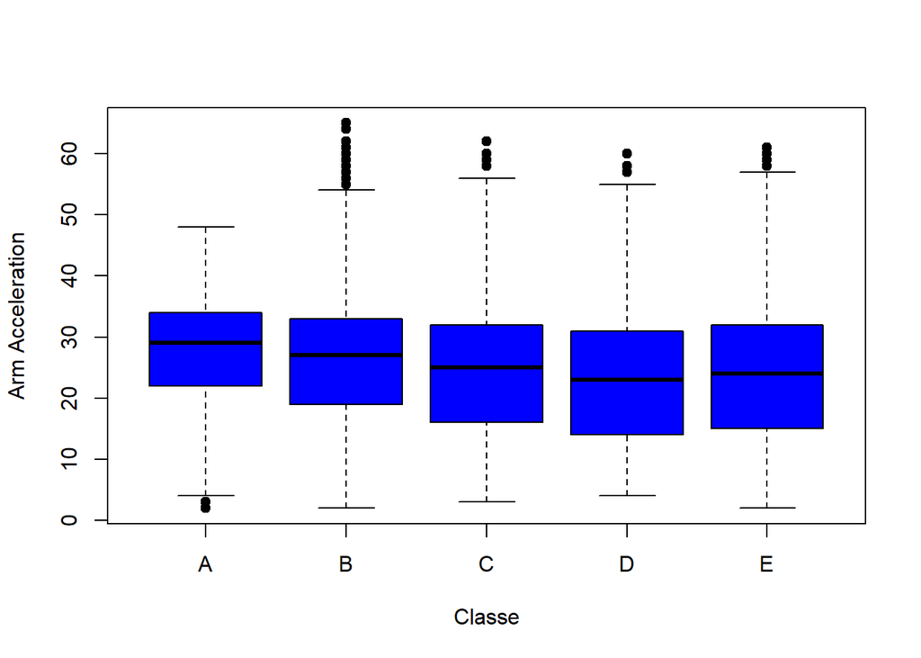

```r
plot(trainexercise$classe, trainexercise$total_accel_arm, pch=19, col="blue", xlab="Classe", ylab="Arm Acceleration")
```

```r
predicted <- predict(lml, testexercise[21:1000, ], type = "response")
testexercise$classe = as.numeric(testexercise$classe)
actual <- testexercise[21:1000, "classe" ]
sqrt(mean(predicted - actual)^2)
```

```
## [1] 1.783479
```